```python
%pylab inline
import numpy as np
from scipy.linalg import eigh
```

# Graph Drawing and Energy Minimization $^{[\mathrm{ref. 1}]}$

Let $G =(V,E)$ be some undirected graph. Say $|\ V\ |=m$. The idea is to assign a point $\rho(v_i)$ in $\mathbb{R}^n$ to the vertex $v_i \in V$, for every $v_i \in V$, and to draw a line segment between the points $\rho(v_i)$ and $\rho(v_j)$. Thus, a *graph drawing* is a function $\rho : V \rightarrow \mathbb{R}^n$.

We define the *matrix of a graph drawing $\rho$ (in $\mathbb{R}^n$)* as a $m\times n$ matrix $R$ whose _i_th row consists of the row vector $\rho(v_i)$ corresponding to the point representation $v_i$ in $\mathbb{R}^n$. Typically, we want $n<m$; in fact $n$ should be much smaller than $n$.

A representation is *balanced* iff the sum of the entries of every column is zero, that is $\boldsymbol{1}^\mathrm{T}R=0$.

**Proposition:** Let $G = (V,W)$ be a weighted graph, with $|\ V\ |=m$ and $W$ an $n\times n$ symmetric matrix, and let $R$ be the matrix of a graph drawing $\rho$ of G in $\mathbb{R}^n$ (a $m\times n$ matrix). If $L=D-W$ is the unnormalized Laplacian matrix associated with $W$, then: $ \mathcal{E}(R)=\mathrm{tr}(R^\mathrm{T}LR).$

```python
def spectral(A):
    D = np.eye(len(A)) * np.array(np.sum(A, axis=1)) # degree matrix
    L = D - A # Laplacian L = degree matrix - adjacency matrix
    w, v = eigh(L) # w = eigenvalues, v = eigenvectors
    x = v[:,1]; y = v[:,2] # spectral coordinates
    return {i: (x[i], y[i]) for i in range(len(A))}

def spectral_matrix(A):
    D = np.eye(len(A)) * np.array(np.sum(A, axis=1)) # degree matrix
    L = D - A # Laplacian L = degree matrix - adjacency matrix
    w, v = eigh(L) # w = eigenvalues, v = eigenvectors
    x = v[:,1]; y = v[:,2] # spectral coordinates
    return np.matrix([x,y])
```

# Examples of Graph Drawings

## Plotting

```python
def gplot(A, S, size=6,c='b',title=''):
    plt.figure(figsize=(size,size))
    for i in range(len(A)):
        for j in range(len(A)):
            if A[i,j] > 0:
                plot((S[i][0], S[j][0]), (S[i][1], S[j][1]), c=c, lw=1)
    x, y = zip(*S.values())
    plot(x, y, 'o', c=c);
    if title: plt.title(title)
```

## Example 1: Square

Consider the graph with four nodes whose adjacency matrix is:

$$ A = \begin{bmatrix} 0 & 1 & 1 & 0 \\ 1 & 0 & 0 & 1 \\ 1 & 0 & 0 & 1 \\ 0 & 1 & 1 & 0 \end{bmatrix}$$

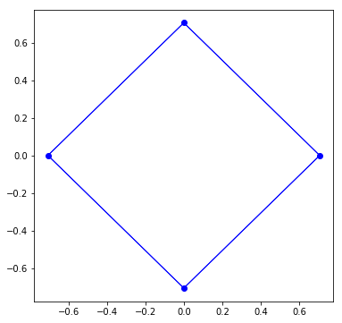

```python
A = np.matrix([[0,1,1,0],[1,0,0,1],[1,0,0,1],[0,1,1,0]]) # adjancency matrix
S = spectral(A)
gplot(A,S)
```

## Example 2: 5-points

Another example with a graph consisting of $5$ points.

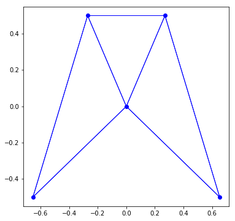

```python
A = np.matrix([[0,1,1,0,0],[1,0,1,1,1],[1,1,0,1,0],[0,1,1,0,1],[0,1,0,1,0]])
S = spectral(A)
gplot(A,S)
```

## Example 3: Complete graph ($K_n)$ of order $n$

In a complete graph $K_n$ of order $n$, all nodes are connected to each other. The adjancency matrix for $K_n$, can be defined as $K_n = \boldsymbol{1}-I$. Which is a square matrix of size $n$, except for the diagonal, which is zero.

```python
def K(n): return np.ones(n) - np.eye(n)
```

Notice that we want to have $n<m$ where $n$ is much smaller. However, we can see that $m=n-1$, which violates that $n$ should be much smaller.

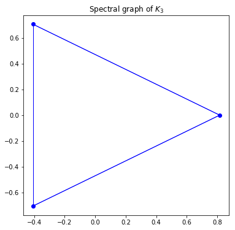

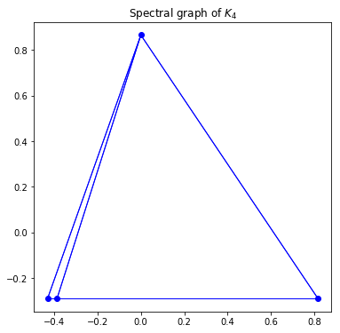

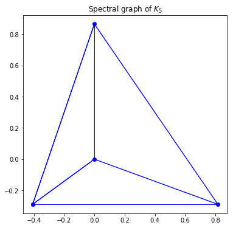

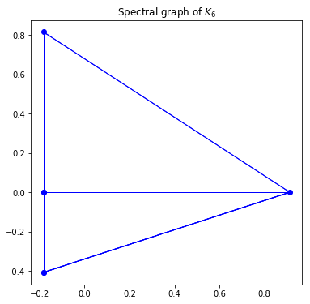

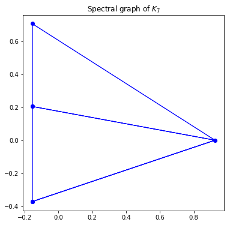

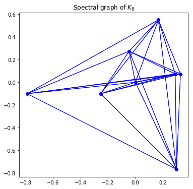

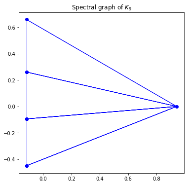

```python
for i in range(3, 10):
    A = K(i)
    S = spectral(A)
    gplot(A,S,title='Spectral graph of $K_{}$'.format(i))
```

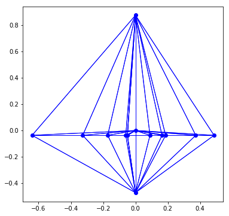

```python
A = K(14)
S = spectral(A)
gplot(A,S)
```

## Example 5: Ring graph

A ring graph is a graph with one cycle, and where the degree of all the nodes is exactly 2. We can create a ring graph adjacency matrix $M$ by constructing the identity matrix $I$. If we shift (and wrap around) all the values in the rows of the matrix, We get that we are going from $A\rightarrow B$, $B\rightarrow C$, and so forth.

```python
A = np.roll(np.eye(4), 1, axis=1)
A
```

```
array([[0., 1., 0., 0.],
       [0., 0., 1., 0.],
       [0., 0., 0., 1.],
       [1., 0., 0., 0.]])
```

Because this is an undirected graph, we should also set the adjacencies for $B\rightarrow A$, $C\rightarrow B$, and so forth. this is easly achieved with $A+A^T$, because the adjacency matrix of an undirected graph is symmetrical.

```python
A + A.T
```

```
array([[0., 1., 0., 1.],
       [1., 0., 1., 0.],
       [0., 1., 0., 1.],
       [1., 0., 1., 0.]])
```

This gives the following function that construct an adjacency matrix for a ring graph of size $n$:

```python
def ring(n):
    A = np.roll(np.eye(n), 1, axis=1)
    return A + A.T
```

If we create a spectral graph of the ring graph, we get the following result:

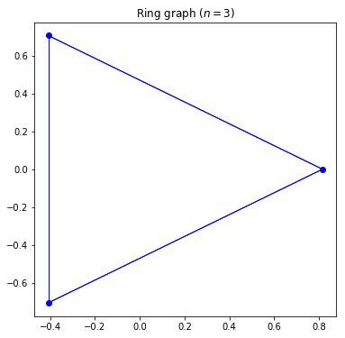

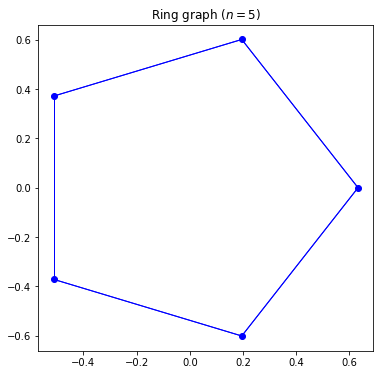

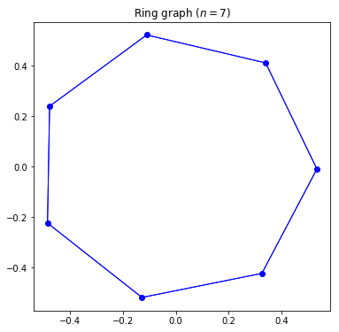

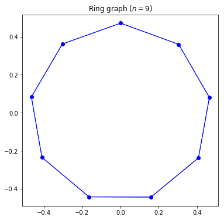

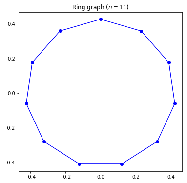

```python
for i in range(3, 12, 2):
    A = ring(i)
    S = spectral(A)
    gplot(A,S, title='Ring graph ($n={}$)'.format(i))
```

# References

The following references have been used:

1. Chapter 18, Spectral Graph Drawing (http://www.cis.upenn.edu/~cis515/cis515-15-graph-drawing.pdf)
2. https://en.wikipedia.org/wiki/Laplacian_matrix
3. https://en.wikipedia.org/wiki/Degree_matrix
4. https://www.johndcook.com/blog/2016/01/15/spectral-coordinates-in-python/